# miaR_babynames

Mia Fusillo

date: 3/31/21

packages and data

```r
library(tidyverse)
library(gridExtra)
library(ggplot2)

load("../data/babynames.rda")
```

Part 1: exploring different types of graphs and plotting sex distribution of names

method #1: line graph

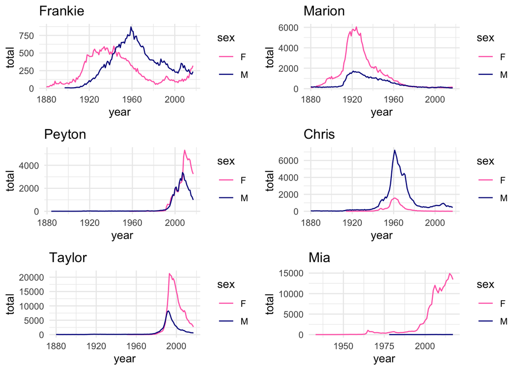

```r
gg_name_line <- function(idname = NULL) {
  ggplot(babynames %>% filter(name==idname),
              aes(x=year, y=n, color=sex)) +
    geom_line() +
    ggtitle(idname) +
    ylab("total") +
    scale_color_manual(values=c("hotpink","darkblue")) +
    theme_minimal()
}

grid.arrange(
  gg_name_line("Frankie"),
  gg_name_line("Marion"),
  gg_name_line("Peyton"),
  gg_name_line("Chris"),
  gg_name_line("Taylor"),
  gg_name_line("Mia")
)
```

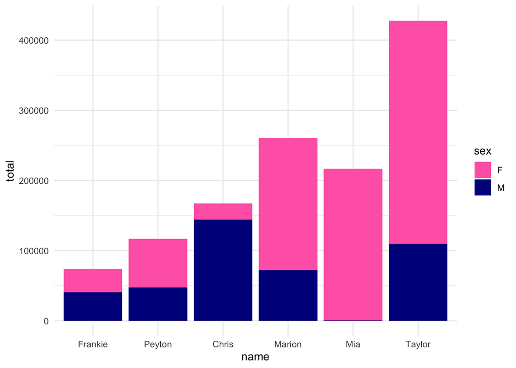

```r
some_names <- c("Frankie", "Marion", "Peyton", "Chris", "Taylor", "Mia")

z <- babynames %>%
  filter(name %in% some_names)

ggplot(z, aes(x=reorder(name, n), y=n, fill=sex)) +
  geom_col() +
  scale_y_continuous(labels=function(x) format(x, scientific=FALSE)) +
  scale_fill_manual(values = c("hotpink", "darkblue")) +
  xlab("name") +
  ylab("total") +
  theme_minimal()
```

method #3: side-by-side bar graph

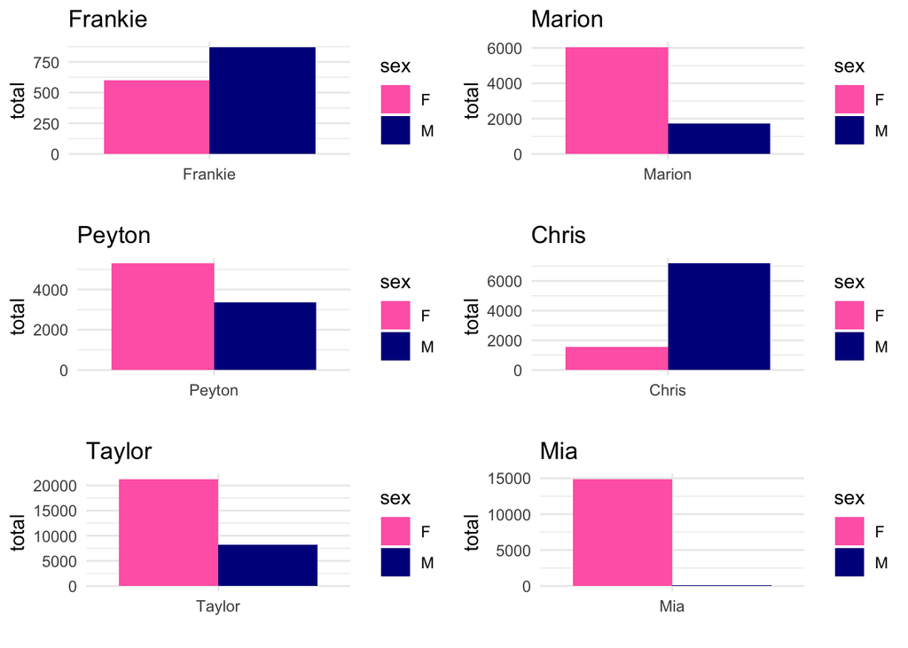

```r
gg_name_col <- function(id2_name = NULL) {
  ggplot(babynames %>% filter(name==id2_name),
              aes(x=id2_name, y=n, fill=sex)) +
    geom_col(position = "dodge") +
    ggtitle(id2_name) +
    scale_fill_manual(values=c("hotpink", "darkblue")) +
    xlab("") +
    ylab("total") +
    scale_y_continuous(labels=function(x) format(x, scientific=FALSE)) +
    theme_minimal()
}

grid.arrange(
  gg_name_col("Frankie"),
  gg_name_col("Marion"),
  gg_name_col("Peyton"),
  gg_name_col("Chris"),
  gg_name_col("Taylor"),
  gg_name_col("Mia")
)
```

method #4: area graph

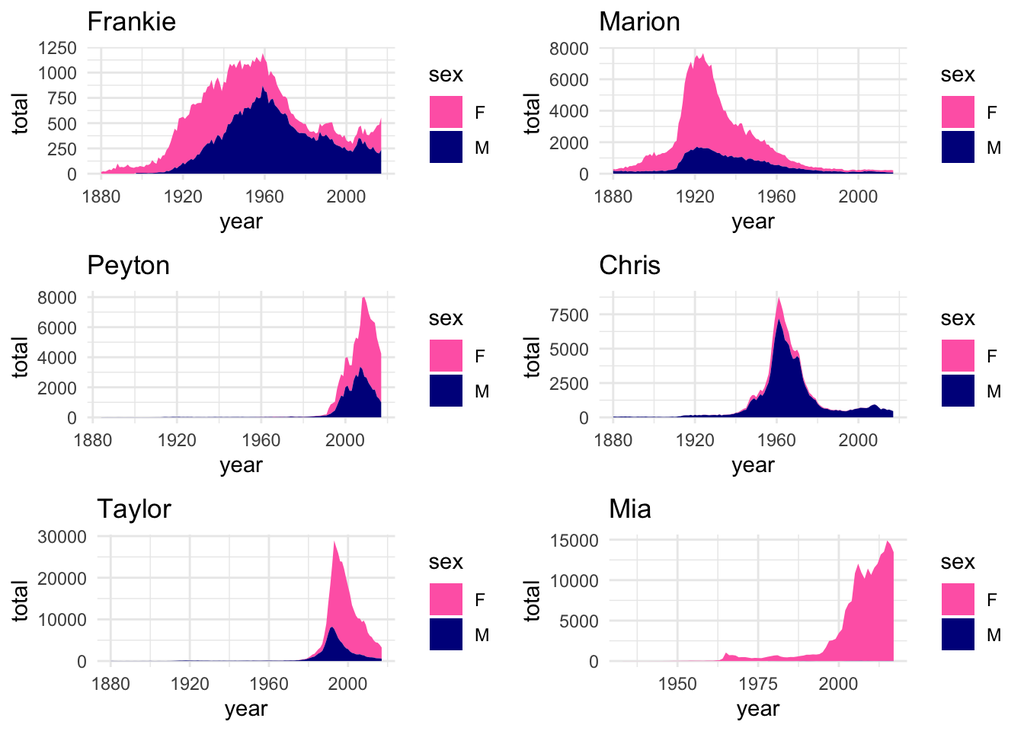

```r
gg_name_area <- function(id3_name=NULL) {
  ggplot(babynames %>% filter(name==id3_name),
         aes(x=year, y=n, fill=sex)) +
    geom_area() +
    ylab("total") +
    ggtitle(id3_name) +
    scale_fill_manual(values = c("hotpink", "darkblue")) +
    theme_minimal()
}

grid.arrange(
  gg_name_area("Frankie"),
  gg_name_area("Marion"),
  gg_name_area("Peyton"),
  gg_name_area("Chris"),
  gg_name_area("Taylor"),
  gg_name_area("Mia")
)
```

method #5: stacked area chart

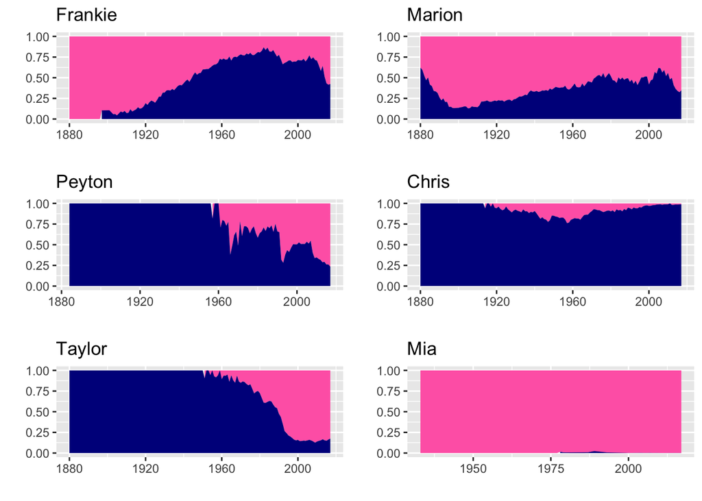

```r
gg_name_area2 <- function(id4_name=NULL) {
  ggplot(babynames %>% filter(name==id4_name),
         aes(x=year, y=n, fill=sex)) +
    geom_area(position="fill") +
    scale_fill_manual(values=c("hotpink", "darkblue")) +
    ggtitle(id4_name) +
    xlab("") +
    ylab("") +
    theme(legend.position = "none")
}

grid.arrange(
  gg_name_area2("Frankie"),
  gg_name_area2("Marion"),
  gg_name_area2("Peyton"),
  gg_name_area2("Chris"),
  gg_name_area2("Taylor"),
  gg_name_area2("Mia")
)
```

Part 2: looking at most common unisex names

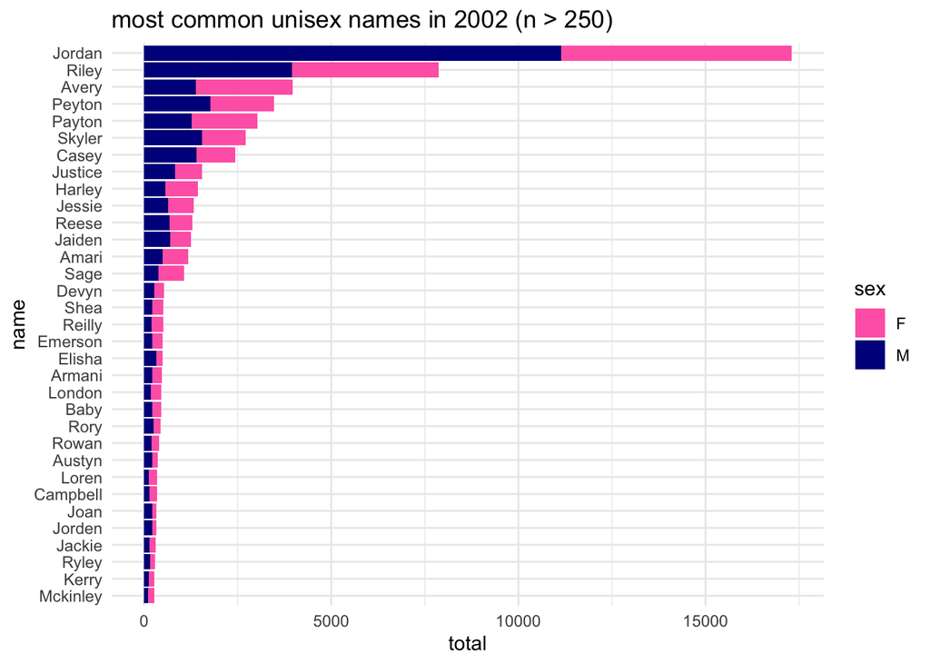

```r
df <- babynames %>%
  filter(year==2002) %>%
  group_by(name, sex) %>%
  summarize(total = sum(n)) %>%
  pivot_wider(
    names_from = sex, values_from = total, values_fill = 0)

colnames(df) <- c("name", "nM", "nF")

df <- df %>% mutate(ratio = nM/(nM + nF), total = nM + nF)

unisex_names <- df %>%
  filter(ratio > .33, ratio < .67, total > 250)

unisex_names <- c("Amari", "Armani", "Austyn", "Avery", "Baby", "Campbell",
                  "Casey", "Devyn", "Elisha", "Emerson", "Harley", "Jackie",
                  "Jaiden", "Jessie", "Joan", "Jordan", "Jorden", "Justice",
                  "Kerry", "London", "Loren", "Mckinley", "Payton", "Peyton",
                  "Reese", "Reilly", "Riley", "Rory", "Rowan", "Ryley",
                  "Sage", "Shea", "Skyler")

p4 <- babynames %>%
  filter(name %in% unisex_names, year==2002)

ggplot(p4, aes(x=reorder(name, n), y=n, fill=sex)) +
  geom_col() +
  coord_flip() +
  ylab("total") +
  xlab("name") +
  ggtitle("most common unisex names in 2002 (n > 250)") +
  scale_fill_manual(values=c("hotpink", "darkblue")) +
  theme_minimal()
```

```r
bn <- babynames %>%
  group_by(year, name, sex) %>%
  summarize(total = sum(n)) %>%
  pivot_wider(names_from = sex, values_from = total, values_fill = 0) %>%
  mutate(ratio = M/(M+`F`), total = M + `F`)

colnames(bn) <- c("year", "name", "nM", "nF", "ratio", "total")

bnames <- unique(bn$name)
## 97, 310 unique babynames
```

Ideas:

1.) emd

2.) find all of the points in time where on sex predominantly covers a name and count how many times a switch happens - use ifelse, rle, and length

3.) Find the year with the highest n value for each sex and name. See if the years are similar (this tells us if peak popularity happened around the same time or not). Then, we can subtract the two years to find the distance the peaks are away from one another. We can also compare n values, to see if the popularity switched from predominantly one sex to the other

Issues:

learn how to repeat a task for every name and then store the results in a list